# Assignment 2: Letter Recognition

Michela Sessi

## Loading CSV Letters

```r
Letters <- read.csv("C:/Users/Michela.S/Desktop/Assignment2/Assignment2/Dataset/Letters.csv")
```

## Predicting the letter B

To warm up, start by predicting whether or not the letter is âB.â First, create a new variable called **IsB** in your dataset, which takes value âYesâ if the letter is B, and âNoâ if the letter is not B. Then randomly split your dataset into a training set and a testing set, putting 50% of the data in each set.

```r
Letters$Isb <- ifelse(Letters$Letter=="B", "yes", "no")
Letters$Isb <- as.factor(Letters$Isb)
set.seed(123) # to get repeatable results.
spl = sample.split(Letters$Isb, SplitRatio = 0.5)
Training = subset(Letters, spl==TRUE)
Testing = subset(Letters, spl==FALSE)
```

- Before building models, let us consider a baseline method that always predicts the most frequent outcome, which is ânot B.â What is the accuracy of this baseline method on the test set?

```r
Testing$notb <- "no"
Testing$notb <- as.factor(Testing$notb)
confusionMatrix(Testing$notb,Testing$Isb)
```

```
## Confusion Matrix and Statistics
##
##           Reference
## Prediction   no  yes
##        no  1175  383
##        yes    0    0
##
##                Accuracy : 0.7542
##                  95% CI : (0.732, 0.7754)
##     No Information Rate : 0.7542
##     P-Value [Acc > NIR] : 0.5137
##
##                   Kappa : 0
##  Mcnemar's Test P-Value : <2e-16
##
##             Sensitivity : 1.0000
##             Specificity : 0.0000
##          Pos Pred Value : 0.7542
##          Neg Pred Value :    NaN
##              Prevalence : 0.7542
##          Detection Rate : 0.7542
##    Detection Prevalence : 1.0000
##       Balanced Accuracy : 0.5000
##
##        'Positive' Class : no
##
```

The accuracy is 0.7542.

- Build a CART tree to predict whether or not a letter is a B, using the training set to build your model. Remember to not use the variable **Letter** as one of the independent variables in the model, as this is related to what we are trying to predict! Select reasonable parameter values for the model, and justify your parameter choices. What is the accuracy of this CART model on the test set?

```r
FormulaCART = Isb ~ Xbox +Ybox + Width + Height + Onpix + Xbar + Ybar + X2bar + Y2bar + XYbar + X2Ybar + XY2bar + Xedge + XedgeYcor + Yedge + YedgeXcor
```

Let start creating a for cycle to choose the better minbucket.

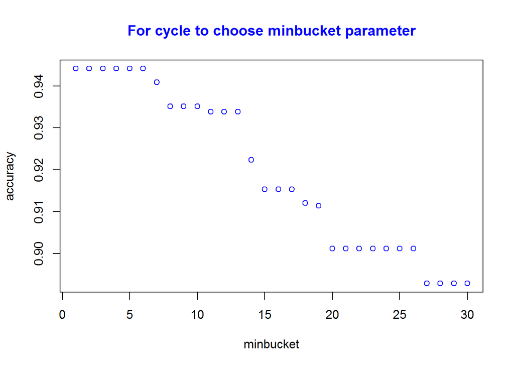

```r
seq = seq( from = 1, to = 30, by = 1)
accuracy<- c()
for (n in seq) {
  DT = rpart(formula = FormulaCART, method="class", data=Training,
              control=rpart.control(minbucket= n))
  predictedDecisions <- predict(DT, Testing, type="class")
  cm <- confusionMatrix(predictedDecisions, Testing$Isb)
  accuracy[n] <- cm$overall[1]}
plot(accuracy, xlab = "minbucket", col= 'blue', main= "For cycle to choose minbucket parameter", col.main='blue')
```

Set the minbucket parameter = 6. In this way we have the better performance with minimum work. For cycle to choose the better maxdepth:

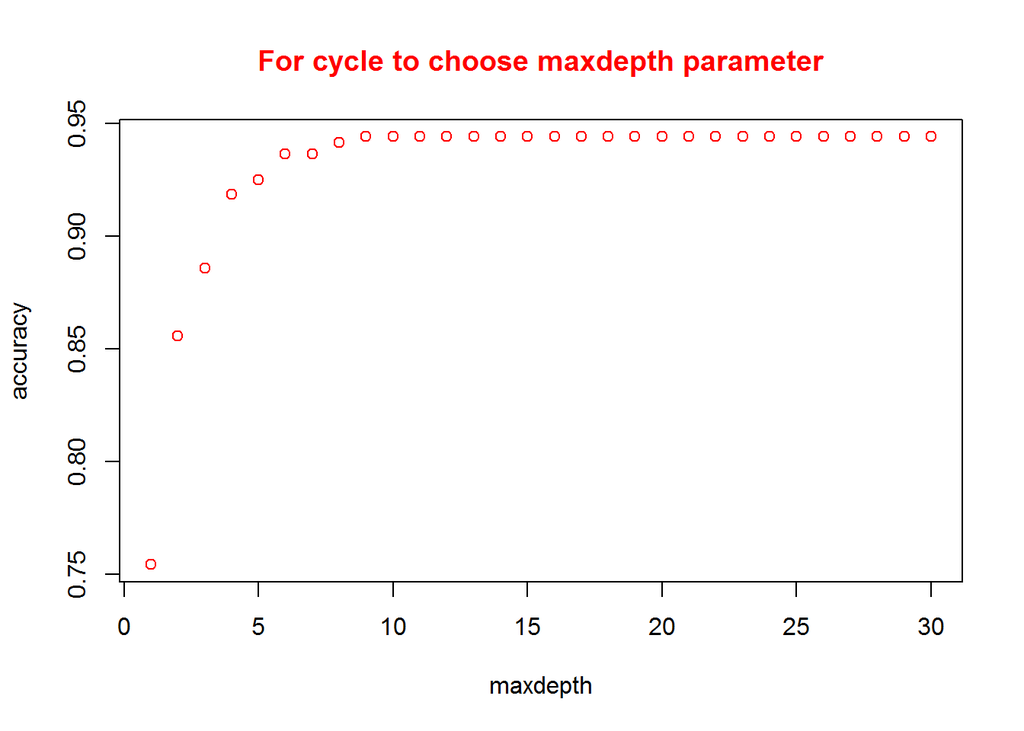

```r
accuracy<- c()
for (n in seq) {
  DT = rpart(formula = FormulaCART, method="class", data=Training,
              control=rpart.control(minbucket = 6,  maxdepth = n))
  predictedDecisions <- predict(DT, Testing, type="class")
  cm <- confusionMatrix(predictedDecisions, Testing$Isb)
  accuracy[n] <- cm$overall[1]}
plot(accuracy, xlab= "maxdepth", ylab= "accuracy", col= "red", main='For cycle to choose maxdepth parameter', col.main='red' )
```

Set the maxdepth parameter = 9. In that way we maximise accuracy with the minimum “maximum depth of any node of the final tree”.

```r
DT = rpart(formula = FormulaCART, method="class", data=Training, control=rpart.control( minbucket=6, maxdepth = 9 ))
printcp(DT)
```

```
##
## Classification tree:
## rpart(formula = FormulaCART, data = Training, method = "class",
##     control = rpart.control(minbucket = 6, maxdepth = 9))
##
## Variables actually used in tree construction:
##  [1] Width     X2bar     X2Ybar    Xbox      Xedge     XedgeYcor XY2bar
##  [8] XYbar     Y2bar     Ybox      Yedge     YedgeXcor
##
## Root node error: 383/1558 = 0.24583
##
## n= 1558
##
##          CP nsplit rel error  xerror     xstd
## 1  0.215405      0   1.00000 1.00000 0.044375
## 2  0.058747      2   0.56919 0.56658 0.035683
## 3  0.027415      4   0.45170 0.53786 0.034909
## 4  0.026110      6   0.39687 0.49347 0.033647
## 5  0.022193      7   0.37076 0.47781 0.033181
## 6  0.019582      9   0.32637 0.44648 0.032215
## 7  0.018277     11   0.28721 0.43864 0.031965
## 8  0.015666     14   0.23238 0.33943 0.028501
## 9  0.013055     15   0.21671 0.28982 0.026510
## 10 0.011749     16   0.20366 0.28982 0.026510
## 11 0.010000     18   0.18016 0.28721 0.026400
```

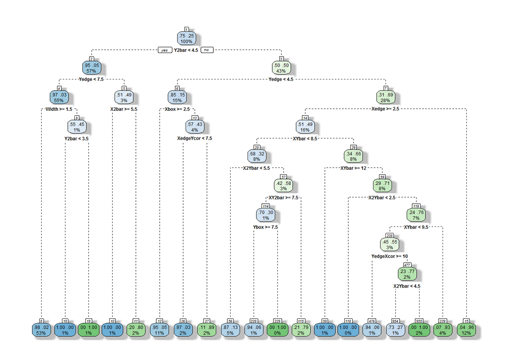

```r
rpart.plot(DT, extra = 105, box.palette = 'auto', branch.lty=2, shadow.col = 'grey', nn=T)
```

This is the accuracy of the training set:

```r
predictedDecisions <- predict(DT,Training,type="class")
cm<- confusionMatrix(predictedDecisions, Training$Isb)
cm$overall[1]
```

```
##  Accuracy
## 0.9557125
```

This is the accuracy of the testing set with a decrease of the 1%:

```r
predictedDecisions <- predict(DT,Testing,type="class")
cm<- confusionMatrix(predictedDecisions, Testing$Isb)
cm$overall[1]
```

```
##  Accuracy
## 0.9441592
```

- Now, build a random forest model to predict whether or not the letter is a B. Again, select reasonable parameter values for the model, and justify your parameter choices. What is the accuracy of the model on the test set?

For the nodesize parameter, I choose the same of the Cart DT. So nodesize = 6.

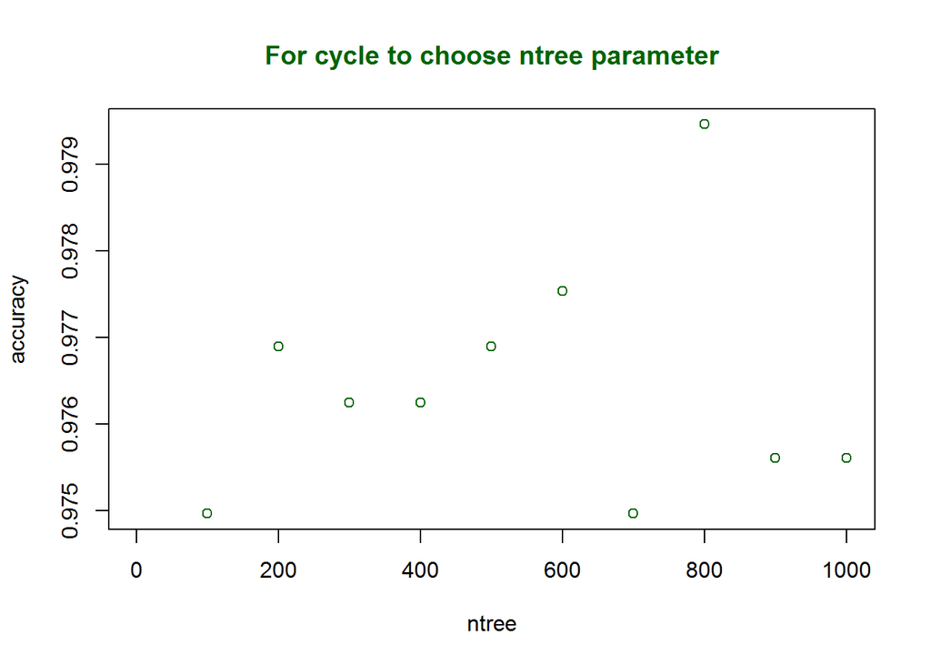

```r
seq1= seq(100, 1000, 100)
accuracy= c()
for (n in seq1) {
  DecisionsDFForest = randomForest(formula = FormulaCART, data = Training, ntree= n, nodesize=6)
  predictedDecisions <- predict(DecisionsDFForest, Testing, type="class")
  cm <- confusionMatrix(predictedDecisions, Testing$Isb)
  accuracy[n] <- cm$overall[1]}
plot(accuracy, col= "darkgreen", main= "For cycle to choose ntree parameter", col.main= 'darkgreen', ylab = "accuracy", xlab="ntree")
```

From the plot, I select the ntree parameter = 800 in order to maximise accuracy.

```r
DecisionsDFForest = randomForest(formula = FormulaCART, data = Training, ntree= 800, nodesize=6)
DecisionsDFForest
```

```
##
## Call:
##  randomForest(formula = FormulaCART, data = Training, ntree = 800,      nodesize = 6)
##                Type of random forest: classification
##                      Number of trees: 800
## No. of variables tried at each split: 4
##
##         OOB estimate of  error rate: 1.99%
## Confusion matrix:
##       no yes class.error
## no  1166   9 0.007659574
## yes   22 361 0.057441253
```

This is the accuracy in the training set:

```r
  predictedDecisions <- predict(DecisionsDFForest, Training, type="class")
  cm <- confusionMatrix(predictedDecisions, Training$Isb)
  cm$overall[1]
```

```
##  Accuracy
## 0.9987163
```

```r
  predictedDecisions <- predict(DecisionsDFForest, Testing, type="class")
  cm <- confusionMatrix(predictedDecisions, Testing$Isb)
  cm$overall[1]
```

```
##  Accuracy
## 0.9768935
```

- Compare the accuracy of your CART and Random Forest models. Which one performs better? For this application, do you think interpretability or accuracy is more important?

$Accuracy CART = 0.9442$

Random Forest permorms better. Accuracy is more important, ’cause we can’t interpret the model in any case. The Cart contain a large number of split and has 9 level: the interpretability is minimum.

## Building a more general predictor

Let us now move on to the problem that we were originally interested in, which is to predict whether or not a letter is one of the four letters A, B. P or R. The variable in our dataset that we will be trying to predict is Letter.

- In a multi-class classification problem, a simple baseline model is to predict the most frequent class of all of the options for every observation. For this problem, what does the baseline method predict, and what is the baseline accuracy on the testing set? Do you think this simple baseline method is a useful benchmark for this problem? Why or why not?

```r
summary(Training$Letter)
```

```
##   A   B   P   R
## 389 383 401 385
```

The letter P has the higher percentage, so the baseline method predict P.

```r
Testing$P <- "P"
confusionMatrix(Testing$P,Testing$Letter)
```

```
## Confusion Matrix and Statistics
##
##           Reference
## Prediction   A   B   P   R
##          A   0   0   0   0
##          B   0   0   0   0
##          P 400 383 402 373
##          R   0   0   0   0
##
## Overall Statistics
##
##                Accuracy : 0.258
##                  95% CI : (0.2364, 0.2805)
##     No Information Rate : 0.258
##     P-Value [Acc > NIR] : 0.5097
##
##                   Kappa : 0
##  Mcnemar's Test P-Value : NA
##
## Statistics by Class:
##
##                      Class: A Class: B Class: P Class: R
## Sensitivity            0.0000   0.0000    1.000   0.0000
## Specificity            1.0000   1.0000    0.000   1.0000
## Pos Pred Value            NaN      NaN    0.258      NaN
## Neg Pred Value         0.7433   0.7542      NaN   0.7606
## Prevalence             0.2567   0.2458    0.258   0.2394
## Detection Rate         0.0000   0.0000    0.258   0.0000
## Detection Prevalence   0.0000   0.0000    1.000   0.0000
## Balanced Accuracy      0.5000   0.5000    0.500   0.5000
```

This method is not useful: the accuracy explain only the 25.8%. Infact the percentage of the letters (A, B, P, R) are similar: we can’t predict the outcome with a baseline method.

- Now build a classification tree to predict Letter, using the training set to build your model. (Remember not to use the variable **IsB** in the model, as this is related to what we are trying to predict!) Select reasonable parameter values and justify your parameter choices. What is the test set accuracy of your CART model? (HINT: When you are computing the test set accuracy using a classification matrix, you want to add everything on the main diagonal and divide by the total number of observations in the test set.)

```r
FormulaCART1 = Letter ~ Xbox +Ybox + Width + Height + Onpix + Xbar + Ybar + X2bar + Y2bar + XYbar + X2Ybar + XY2bar + Xedge + XedgeYcor + Yedge + YedgeXcor
```

Let start creating a for cycle to choose the better minbucket.

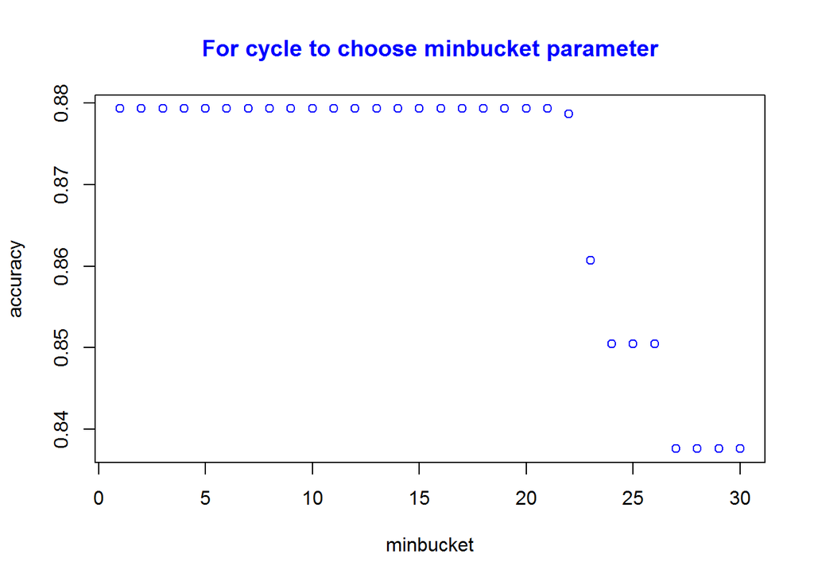

```r
accuracy<- c()
for (n in seq) {
  DT = rpart(formula = FormulaCART1, method="class", data=Training,
              control=rpart.control(minbucket= n))
  predictedDecisions <- predict(DT, Testing, type="class")
  cm <- confusionMatrix(predictedDecisions, Testing$Letter)
  accuracy[n] <- cm$overall[1]}
plot(accuracy, xlab = "minbucket", col= 'blue', main= "For cycle to choose minbucket parameter", col.main='blue')
```

Set the minbucket parameter = 21. In this way we have the better performance with minimum work. For cycle to choose the better maxdepth:

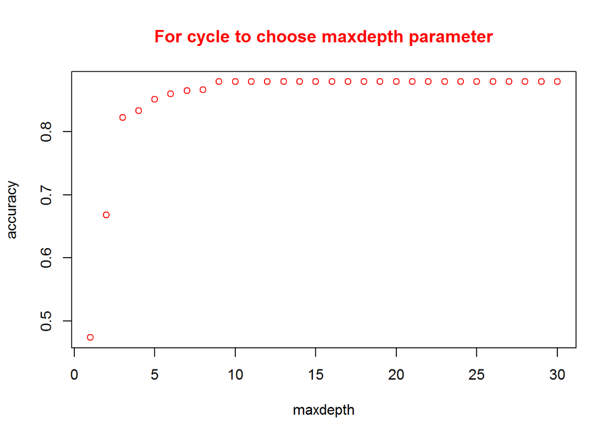

```r
accuracy<- c()
for (n in seq) {
  DT = rpart(formula = FormulaCART1, method="class", data=Training,
              control=rpart.control(minbucket = 21,  maxdepth = n))
  predictedDecisions <- predict(DT, Testing, type="class")
  cm <- confusionMatrix(predictedDecisions, Testing$Letter)
  accuracy[n] <- cm$overall[1]}
plot(accuracy, xlab= "maxdepth", ylab= "accuracy", col= "red", main='For cycle to choose maxdepth parameter', col.main='red' )
```

Set the maxdepth parameter = 9. In that way we maximise accuracy with the minimum “maximum depth of any node of the final tree”.

```r
DT = rpart(formula = FormulaCART1, method="class", data=Training, control=rpart.control (minbucket=21, maxdepth = 9))
printcp(DT)
```

```
##
## Classification tree:
## rpart(formula = FormulaCART1, data = Training, method = "class",
##     control = rpart.control(minbucket = 21, maxdepth = 9))
##
## Variables actually used in tree construction:
## [1] X2bar     Xedge     XedgeYcor XY2bar    Y2bar     Ybar      Yedge
##
## Root node error: 1157/1558 = 0.74262
##
## n= 1558
##
##         CP nsplit rel error  xerror     xstd
## 1 0.277442      0   1.00000 1.00000 0.014915
## 2 0.276577      1   0.72256 0.60674 0.016974
## 3 0.194468      2   0.44598 0.44685 0.016064
## 4 0.014693      3   0.25151 0.25151 0.013296
## 5 0.013829      4   0.23682 0.22731 0.012779
## 6 0.013397      5   0.22299 0.22731 0.012779
## 7 0.010372      8   0.18237 0.20052 0.012145
## 8 0.010000     11   0.15125 0.20052 0.012145
```

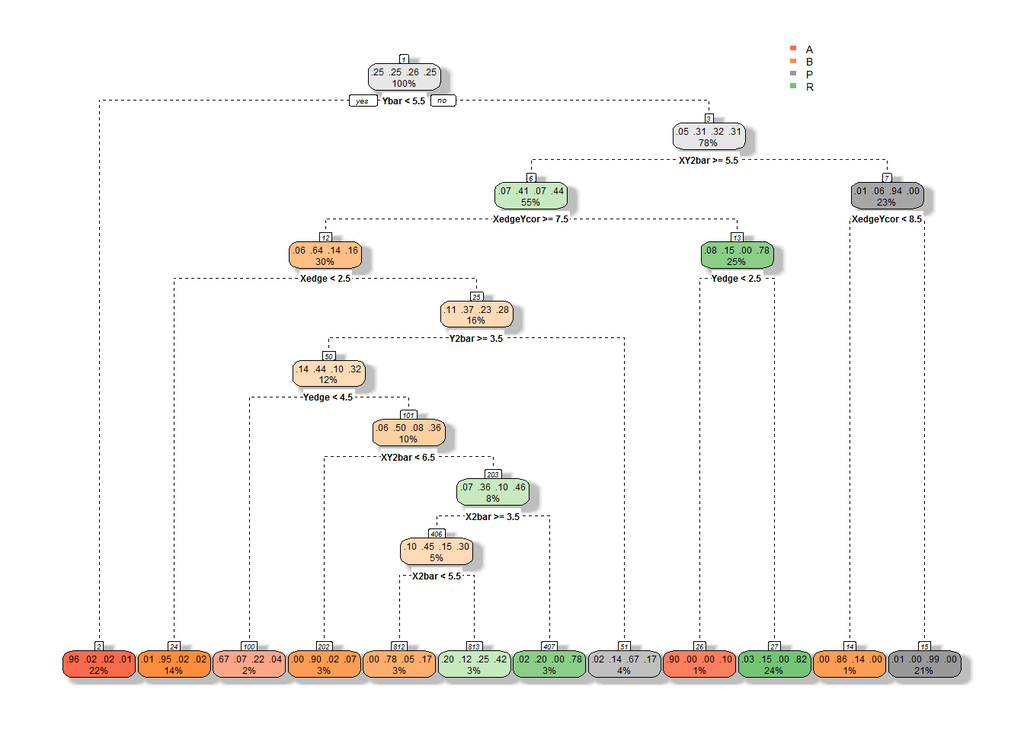

```r
rpart.plot(DT, extra = 105, box.palette = 'auto', branch.lty=2, shadow.col = 'grey', nn=T)
```

This is the accuracy of the training set

```r
predictedDecisions <- predict(DT,Training,type="class")
cm<- confusionMatrix(predictedDecisions, Training$Letter)
cm$overall[1]
```

```
##  Accuracy
## 0.8876765
```

This is the accuracy of the testing set with a decrease of the 0.8%.

```r
predictedDecisions <- predict(DT,Testing,type="class")
cm<- confusionMatrix(predictedDecisions, Testing$Letter)
cm$overall[1]
```

```
##  Accuracy
## 0.8793325
```

- Now, build a random forest model to predict **Letter**, using the training data - again, do not forget to remove the **IsB** variable. What is the test set accuracy of your random forest model?

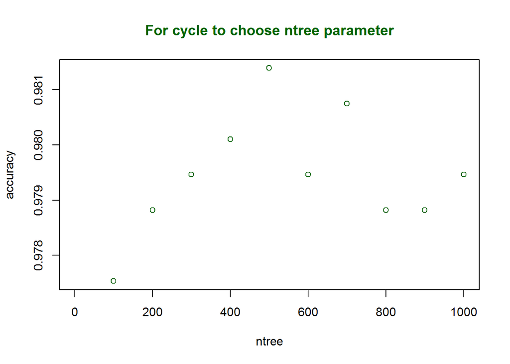

```r
accuracy= c()
for (n in seq1) {
  DecisionsDFForest = randomForest(formula = FormulaCART1, data = Training, ntree= n,           nodesize=6)
  predictedDecisions <- predict(DecisionsDFForest, Testing, type="class")
  cm <- confusionMatrix(predictedDecisions, Testing$Letter)
  accuracy[n] <- cm$overall[1]}
plot(accuracy, col= "darkgreen", main= "For cycle to choose ntree parameter", col.main= 'darkgreen', ylab = "accuracy", xlab="ntree")
```

From the plot, I select the ntree parameter = 500 in order to maximise accuracy.

```r
DecisionsDFForest = randomForest(formula = FormulaCART1, data = Training, ntree= 500, nodesize=6)
DecisionsDFForest
```

```
##
## Call:
##  randomForest(formula = FormulaCART1, data = Training, ntree = 500,      nodesize = 6)
##                Type of random forest: classification
##                      Number of trees: 500
## No. of variables tried at each split: 4
##
##         OOB estimate of  error rate: 2.12%
## Confusion matrix:
##     A   B   P   R class.error
## A 387   0   2   0 0.005141388
## B   1 368   2  12 0.039164491
## P   0   4 397   0 0.009975062
## R   0  12   0 373 0.031168831
```

This is the accuracy in the training set:

```r
  predictedDecisions <- predict(DecisionsDFForest, Training, type="class")
  cm <- confusionMatrix(predictedDecisions, Training$Letter)
  cm$overall[1]
```

```
##  Accuracy
## 0.9987163
```

```r
  predictedDecisions <- predict(DecisionsDFForest, Testing, type="class")
  cm <- confusionMatrix(predictedDecisions, Testing$Letter)
  cm$overall[1]
```

```
##  Accuracy
## 0.9801027
```

- Compare the accuracy of your CART and Random Forest models for this problem. Which one would you recommend for this problem? Is your choice different from the model you recommended for letter B?

$Accuracy CART = 0.8793$

Random Forest permorms better. With this analysis we can conclude that for both cases we suggests Random Forest.